# Predicting dx and lx Using 1980 CSO Table

Group 1

25 July 2019

## Introduction

The goal of this study is to evaluate the prediction of dx and lx based on 1980 CSO table using time series analysis.

The commissioners standard ordinary (CSO) mortality table reflects the probability that people in various age groups will die in a given year. The CSO table used contains three variables - Age, lx and dx. Age represent person’s age from 0 to 99. Lx represent number of suriviving to age x while dx is the number of dying between ages x to x +1.

We will try to forecast dx and lx for ages from 51 to 99 using historical data points of ages 0-50 using time series forecasting model ARIMA.

ARIMA stands for Autoregressive Integrated Moving Average. ARIMA is also known as Box-Jenkins approach. Box and Jenkins claimed that non-stationary data can be made stationary by differencing the series, Yt. The general model for Yt is written as,

Yt =ϕ1Yt−1 +ϕ2Yt−2…ϕpYt−p +ϵt + θ1ϵt−1+ θ2ϵt−2 +…θqϵt−q

The ARIMA model combines three basic methods:

- AutoRegression (AR) – In auto-regression the values of a given time series data are regressed on their own lagged values, which is indicated by the “p” value in the model.
- Differencing (I-for Integrated) – This involves differencing the time series data to remove the trend and convert a non-stationary time series to a stationary one. This is indicated by the “d” value in the model. If d = 1, it looks at the difference between two time series entries, if d = 2 it looks at the differences of the differences obtained at d = 1, and so forth.
- Moving Average (MA) – The moving average nature of the model is represented by the “q” value which is the number of lagged values of the error term.

This model is called Autoregressive Integrated Moving Average or ARIMA(p,d,q) of Yt. We will follow the steps enumerated below to build our model.

1. Data exploration and visualization.
2. Testing and ensuring stationarity.
3. Identification of model parameters.
4. Building the model.
5. Forecasting

### 1. Data Exploration and Visualization

As a first step, we will read the CSO data from csv file via url path. To get idea of the data content, we will display the first few record of the dataset

```r
# Read 1980 CSO data from URL
file_path = "https://raw.githubusercontent.com/edsonfajilagot/PUPMAS-Demog-Predictive/master/1980_CSO.csv"
cso = read.csv(file_path, header = TRUE, stringsAsFactors = FALSE)

# Display first 6 records
print(head(cso))
```

```
##   Age       lx    dx
## 1   0 10000000 41800
## 2   1  9958200 10656
## 3   2  9947544  9849
## 4   3  9937695  9739
## 5   4  9927956  9432
## 6   5  9918524  8927
```

```r
# Display data table structure information
str(cso)
```

```
## 'data.frame':    100 obs. of  3 variables:
##  $ Age: int  0 1 2 3 4 5 6 7 8 9 ...
##  $ lx : int  10000000 9958200 9947544 9937695 9927956 9918524 9909597 9901074 9893153 9885634 ...
##  $ dx : int  41800 10656 9849 9739 9432 8927 8523 7921 7519 7316 ...
```

We are interested on column dx which is the number of deaths between ages x to x+1. This information is converted into a time series data with frequency = 1 or yearly.

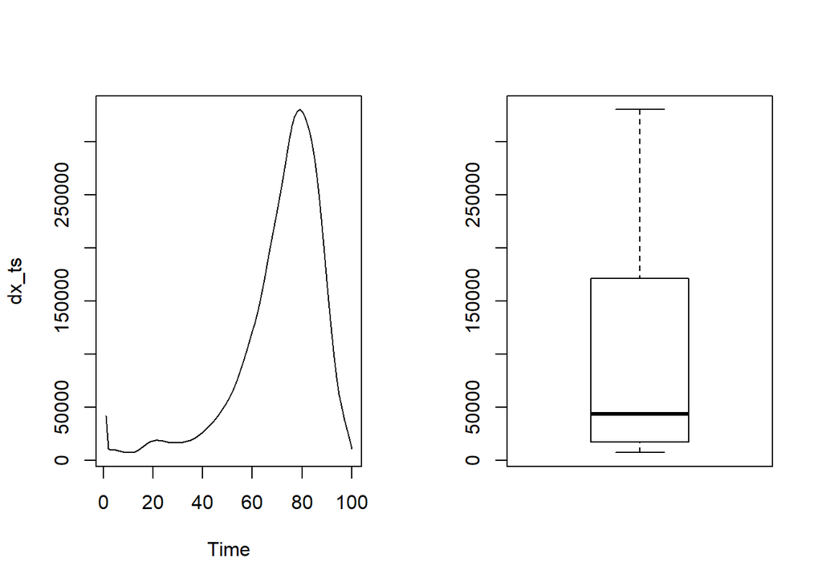

```r
# Get dx, number of death prior next year
dx = cso$dx

# Convert to time series
dx_ts <- ts(dx)

# Plot the time series data
par(mfrow=c(1,2))
plot(dx_ts, type ="l")
boxplot(dx_ts)
```

```r
# Data summary
summary(dx_ts)
```

```
##    Min. 1st Qu.  Median    Mean 3rd Qu.    Max.
##    7212   17346   43508  100000  170060  329935
```

#### Observations

1. It can be noticed that the number of deaths for age 0-1 is quite high. From age 1-60 the number of death is increasing and will reach its peak during the age of 75-80. It shows that the data is in quadratic trend.
2. There is no seasonal pattern or trend, cycle presents as the data is recorded in a yearly basis.
3. The mean and the variance is not constant over time which suggest the series is not stationary.

## 2. Testing and Ensuring Stationarity

To model a time series with the Box-Jenkins approach, the series has to be stationary. A stationary time series means a time series without trend, one having a constant mean and variance over time, which makes it easy for predicting values.

To test for stationarity, we will check the autocorrelation and perform Augmented Dickey-Fuller unit root test (ADF). A stationary time series will have the autocorrelation fall to zero fairly quickly but for a non-stationary series it drops gradually. With ADF test, the p-value resulting from the ADF test has to be less than 0.05.

It shows that the original series is non stationary. That is ACF drops gradually and ADF test failed to reject the null hypothesis.

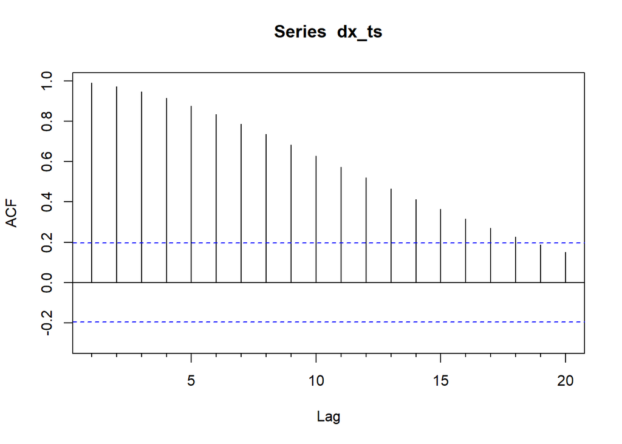

```r
# Check for autocorrelation
Acf(dx_ts)
```

```r
# ADF test
adf.test(dx_ts)
```

```
##
##  Augmented Dickey-Fuller Test
##
## data:  dx_ts
## Dickey-Fuller = -0.87559, Lag order = 4, p-value = 0.9521
## alternative hypothesis: stationary
```

#### Differencing

To convert a non-stationary series to stationary, we apply the differencing method. Differencing a time series means finding the differences between consecutive values of a time series data. The differenced values form a new time series dataset which can be tested to uncover new correlations or other interesting statistical properties.

Getting the first difference still shows non stationarity. The series still exhibits a long term trend (autocorrelations are positive out to a high number of lags, 11 in this case). This suggest we need higher order of differencing.

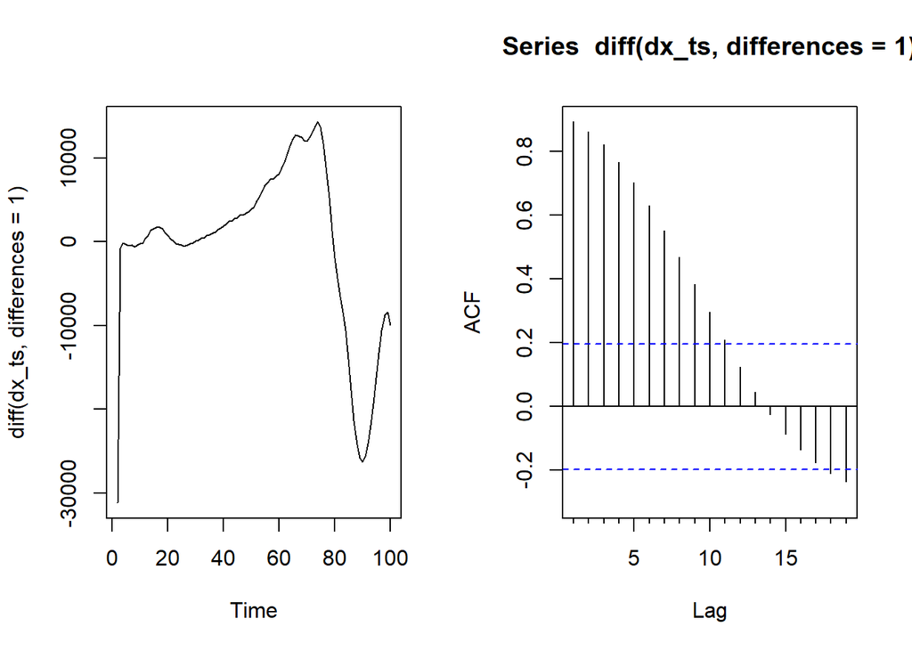

```r
par(mfrow = c(1,2))

# Differencing by first order
plot(diff(dx_ts, differences = 1))
Acf(diff(dx_ts, differences = 1))
```

```r
# ADF test
adf.test(diff(dx_ts, differences = 1))
```

```
##
##  Augmented Dickey-Fuller Test
##
## data:  diff(dx_ts, differences = 1)
## Dickey-Fuller = -0.24694, Lag order = 4, p-value = 0.99
## alternative hypothesis: stationary
```

Differencing of second-order resulted to a stationary data. This makes sense as second-order differencing addresses quadratic trends. With this, our d parameter = 2.

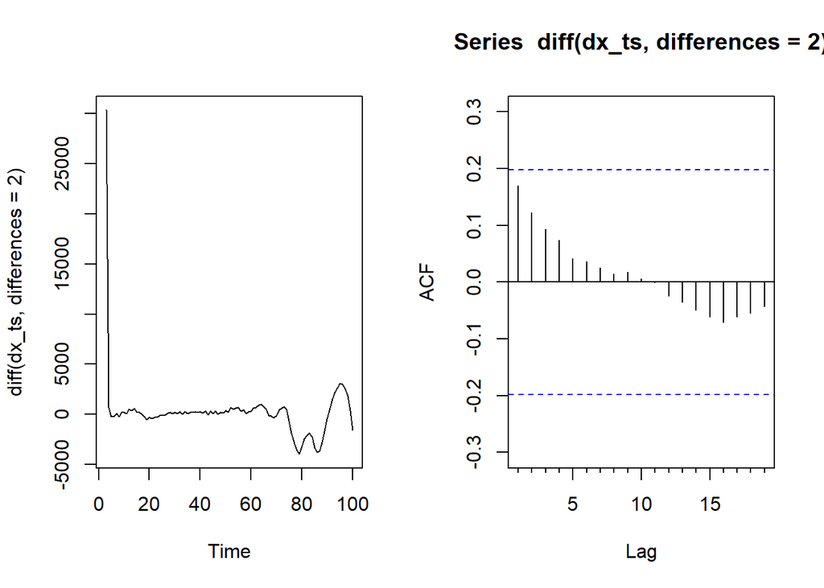

```r
par(mfrow=c(1,2))

# Differencing by second order
plot(diff(dx_ts, differences = 2))
Acf(diff(dx_ts, differences = 2))
```

```r
# ADF test
adf.test(diff(dx_ts, differences = 2))
```

```
##
##  Augmented Dickey-Fuller Test
##
## data:  diff(dx_ts, differences = 2)
## Dickey-Fuller = -3.4737, Lag order = 4, p-value = 0.04816
## alternative hypothesis: stationary
```

## 3. Identification of ARIMA(p,d,q) model parameters

In this step, we identify the appropriate order of Autoregressive (AR) and Moving average (MA) processes by using the Autocorrelation function (ACF) and Partial Autocorrelation function (PACF)

To get the AR order p. If the PACF cuts off after some lags, that number is the order of AR.

We can determine the MA order q by looking at the sample ACF (auto correlation) of the differenced data. If the ACF cuts off after some lags, that number is the order of MA.

Evaluation belows suggest our model to be ARIMA(3,2,0). Our model then is an AR(3) process with second-order differencing.

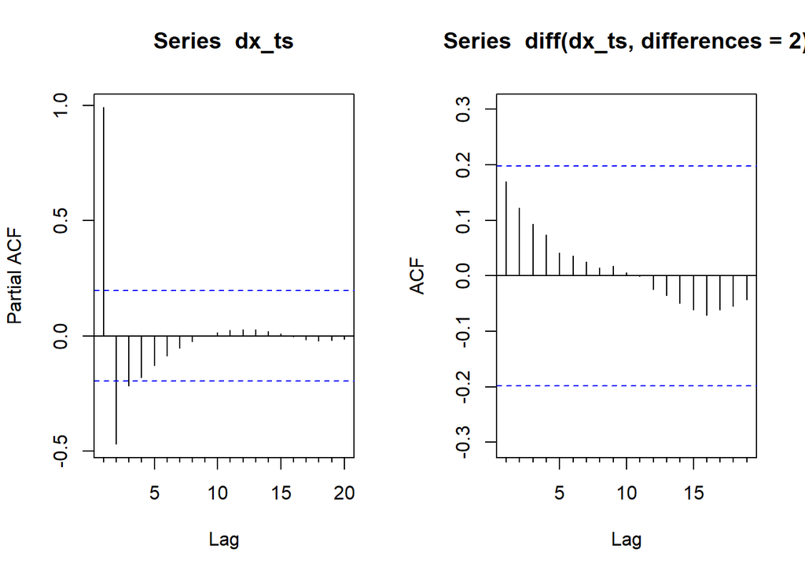

```r
# From differencing, d = 2

par(mfrow = c(1,2))
Pacf(dx_ts)
# AR(3)

Acf(diff(dx_ts, differences = 2))
```

```r
# MA(0)

# Our model then is ARIMA(3,2,0)
```

We can also get the suggested parameters using auto.arima() function. This suggest our model to be ARIMA(2,2,0). This is an AR(2) process with second-order differencing.

```r
auto.arima(dx_ts)
```

```
## Series: dx_ts
## ARIMA(2,2,0)
##
## Coefficients:
##          ar1      ar2
##       1.5586  -0.7087
## s.e.  0.3009   0.2660
##
## sigma^2 estimated as 8970320:  log likelihood=-924.1
## AIC=1854.19   AICc=1854.45   BIC=1861.95
```

## 4. Building the model

Let us make 2 models. That is - ARIMA(3,2,0) and ARIMA(2,2,0). We use the first 50 observation and then forecast the 49 observations for dx from age 51 to 99. We split the data into train data and test data.

Our AR model equations are:

- ARIMA(3,2,0) : yt = 1.17yt−1 - 0.64yt−2 + 0.15yt−3 + ϵt
- ARIMA(2,2,0) : yt = 1.05yt−1 - 0.43yt−2 + ϵt

```r
# Get train and test data
dx_train <- ts(dx_ts[1:50])
#dx_test <- ts(dx_ts[51:60], start = 51, end = 60)  #10
#dx_test <- ts(dx_ts[51:80], start = 51, end = 80)  #30
dx_test <- ts(dx_ts[51:99], start = 51, end = 99)  #49

# Make arima model
arimaModel_1 = arima(dx_train, order=c(3,2,0))
arimaModel_2 = arima(dx_train, order=c(2,2,0))


# Look at the parameters
print(arimaModel_1)
```

```
##
## Call:
## arima(x = dx_train, order = c(3, 2, 0))
##
## Coefficients:
##          ar1      ar2     ar3
##       1.1695  -0.6408  0.1488
## s.e.  0.8997   1.0118  0.5781
##
## sigma^2 estimated as 18125873:  log likelihood = -469.91,  aic = 947.82
```

```r
print(arimaModel_2)
```

```
##
## Call:
## arima(x = dx_train, order = c(2, 2, 0))
##
## Coefficients:
##          ar1      ar2
##       1.0479  -0.4313
## s.e.  0.7325   0.5367
##
## sigma^2 estimated as 18229135:  log likelihood = -469.94,  aic = 945.89
```

## 5. Forecasting

Using the 2 models, we will forecast the value of dx for age 51-99.

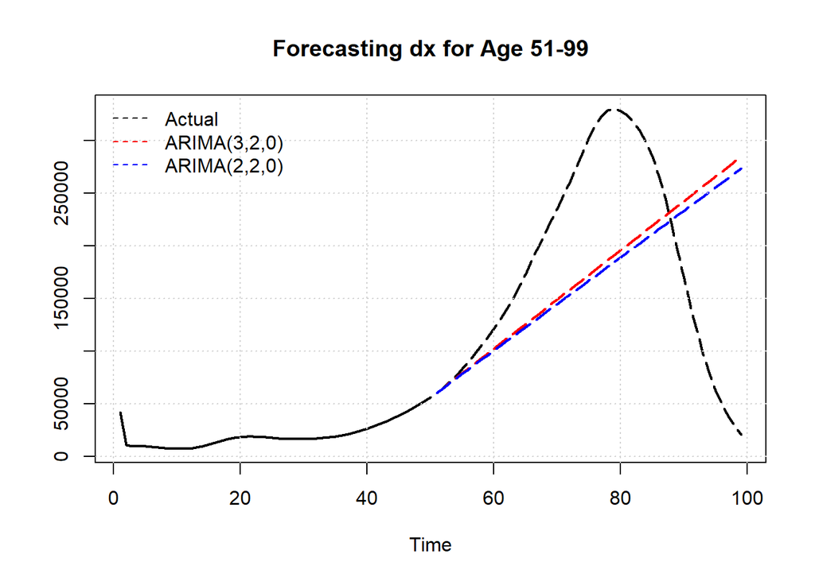

```r
# forecast
forecast1=predict(arimaModel_1, 49) #10,30,49
forecast2=predict(arimaModel_2, 49)

#fcast1 <- forecast(arimaModel_1, 10)
#plot(fcast1)


ts.plot(dx_train, dx_test, forecast1$pred, forecast2$pred, lty = c(1,5,5,5), lwd=c(2,2,2,2), col=c("black","black","red","blue"), main= "Forecasting dx for Age 51-99")
grid()
legend("topleft", bty="n", col = c("black", "red", "blue"), legend = c("Actual", "ARIMA(3,2,0)", "ARIMA(2,2,0)"), lty = c(2, 2, 2))
```

From the forecast point of view, the second model ARIMA(2,2,0) seems to be more accurate but with very small margin of difference vs. model 1. We can evaluate the forecast accurary by comparing the test series vs the predicted values as shown below. It shows that the two model is almost identical.

```r
accmeasures1=regr.eval(dx_test, forecast1$pred)
accmeasures2=regr.eval(dx_test, forecast2$pred)
accMeasure=rbind(accmeasures1, accmeasures2)
print(accMeasure)
```

```
##                   mae         mse     rmse     mape
## accmeasures1 87342.49 12617733528 112328.7 1.051569
## accmeasures2 87953.48 12390964770 111314.7 1.020938
```

## Predicting lx

For predicting lx, we got stationary data with differencing = 4 and AR(2)

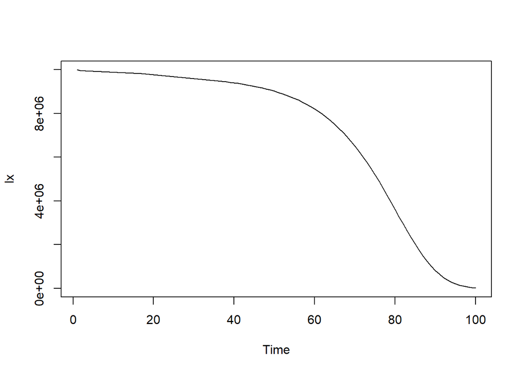

```r
lx <- ts(cso$lx)
plot(lx)
```

## lx model

```r
# Get train and test data
lx_train <- ts(lx[1:50])
#dx_test <- ts(dx_ts[51:60], start = 51, end = 60)  #10
#dx_test <- ts(dx_ts[51:80], start = 51, end = 80)  #30
lx_test <- ts(lx[51:99], start = 51, end = 99)  #49

# Make arima model
arimaModel_1 = arima(lx_train, order=c(2,4,0))

# Look at the parameters
print(arimaModel_1)
```

```
##
## Call:
## arima(x = lx_train, order = c(2, 4, 0))
##
## Coefficients:
##          ar1      ar2
##       0.4056  -0.1592
## s.e.  0.7097   0.5498
##
## sigma^2 estimated as 24963864:  log likelihood = -460.33,  aic = 926.65
```

## lx forecasting

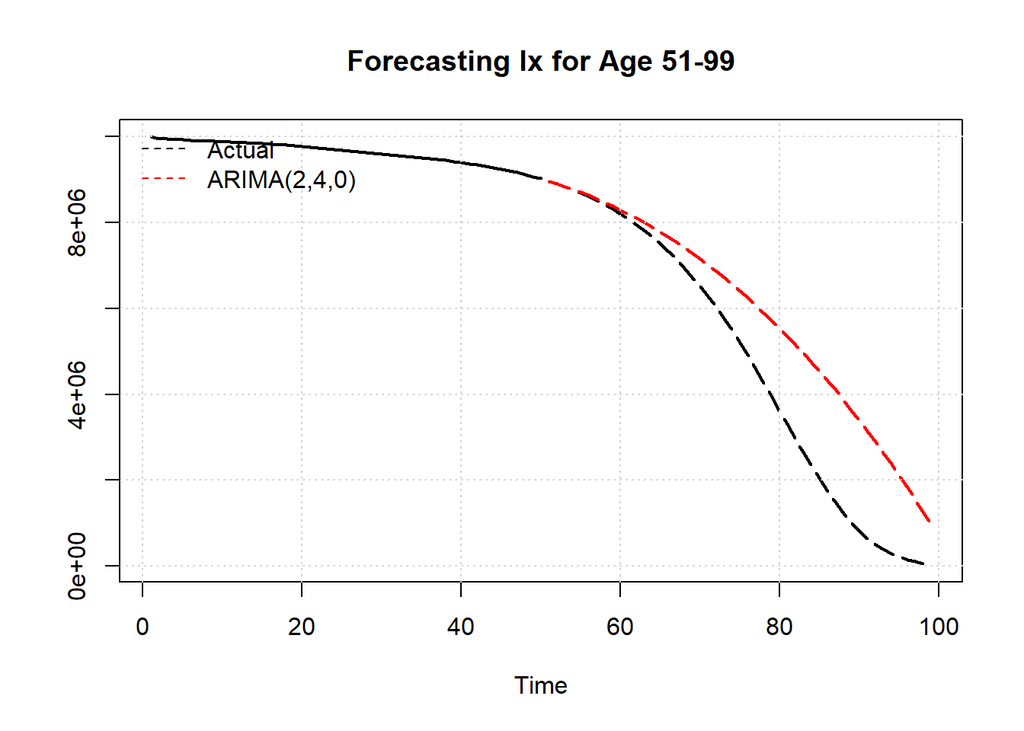

```r
# forecast
forecast1=predict(arimaModel_1, 49) #10,30,49


ts.plot(lx_train, lx_test, forecast1$pred, lty = c(1,5,5), lwd=c(2,2,2), col=c("black","black","red"), main= "Forecasting lx for Age 51-99")
grid()
legend("topleft", bty="n", col = c("black", "red"), legend = c("Actual", "ARIMA(2,4,0)"), lty = c(2, 2))
```

## Conclusion

It shows that ARIMA model, or AR process for this case is not reliable for predicting dx and lx for ages 51-99.